# Using DLMs to model changing seasonality

As discussed in Section @ref(sec-msscov-season-fourier) in the covariates chapter, we can model season with sine and cosine covariates.

$$y_t = x_t + \beta_1 \sin(2 \pi t/p) + \beta_2 \cos(2 \pi t/p) + e_t$$
where $t$ is the time step (1 to length of the time series) and $p$ is the frequency of the data (e.g. 12 for monthly data). $\alpha_t$ is the mean level about which the data $y_t$ are fluctuating.

We can simulate data like this as follows:

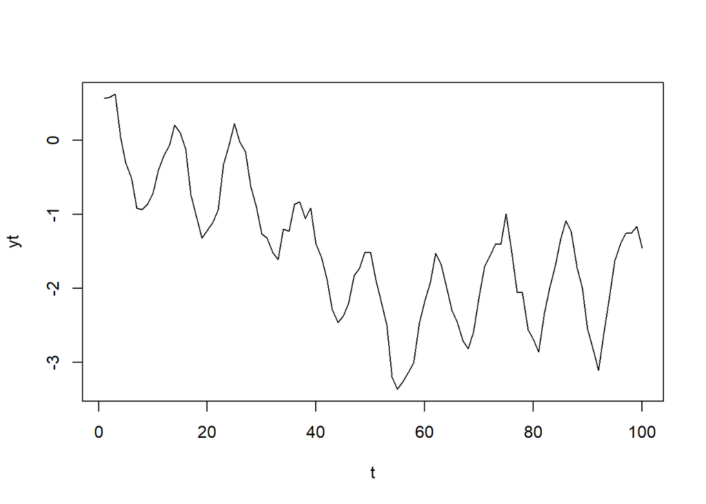

```r
set.seed(1234)
TT <- 100
q <- 0.1; r <- 0.1
beta1 <- 0.6
beta2 <- 0.4
cov1 <- sin(2*pi*(1:TT)/12)
cov2 <- cos(2*pi*(1:TT)/12)
xt <- cumsum(rnorm(TT,0,q))
yt <- xt + beta1*cov1 + beta2*cov2 + rnorm(TT,0,r)
plot(yt, type="l", xlab="t")
```

In this case, the seasonal cycle is constant over time since $\beta_1$ and $\beta_2$ are fixed (not varying in time).

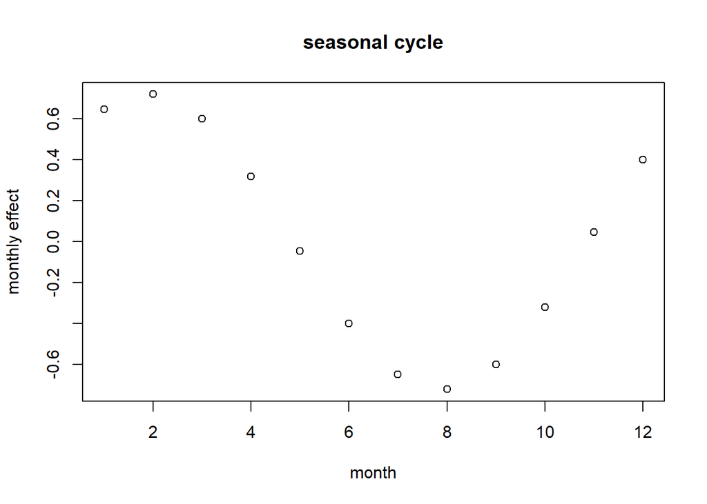

The $\beta$ determine the shape and amplitude of the seasonal cycle—though in this case we will only have one peak per year.

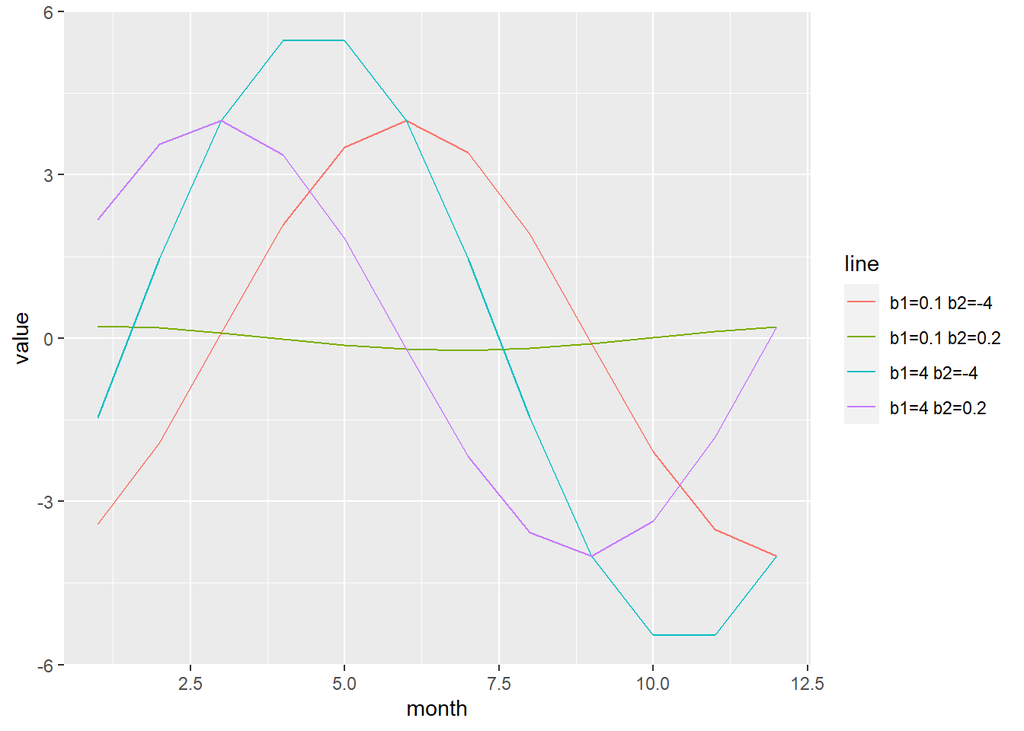

## Time-varying season

If $\beta_1$ and $\beta_2$ vary in time then the seasonal cycle also varies in time. Let’s imagine that $\beta_1$ varies from -1 to 1 over our 100 time steps while $\beta_2$ varies from 1 to -1.

So the seasonal cycle flips between the start and end of our time series.

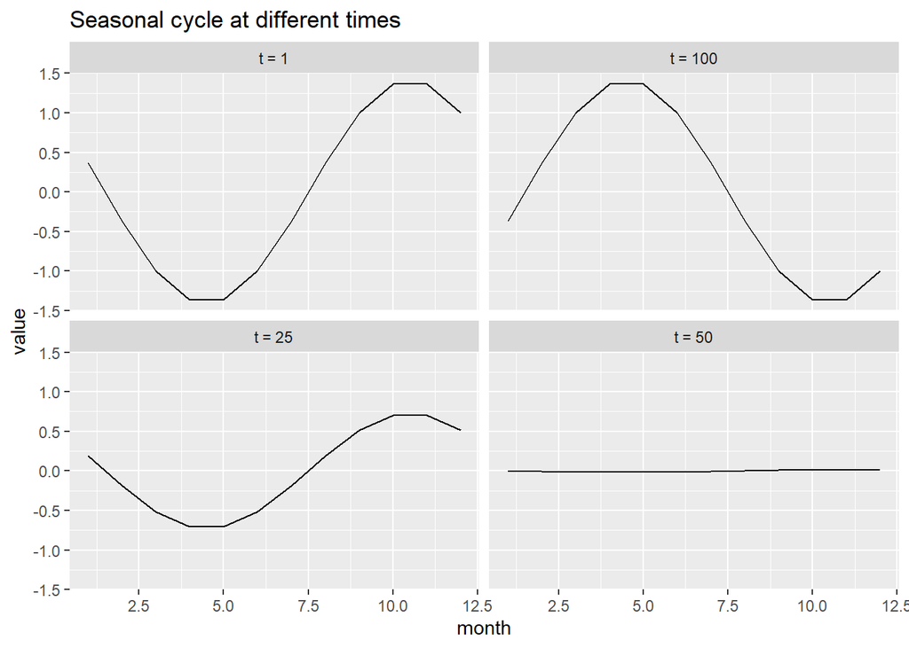

A time series simulated with that flip looks like so:

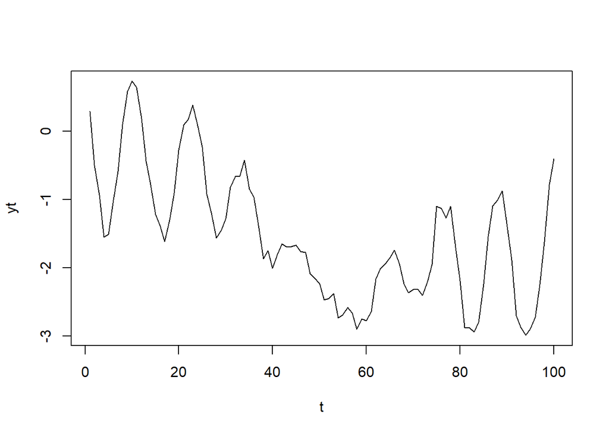

## Using DLMs to estimate changing season

Here is a DLM model with the level and season modeled as a random walk.

$$\begin{bmatrix}x \\ \beta_1 \\ \beta_2 \end{bmatrix}_t = \begin{bmatrix}x \\ \beta_1 \\ \beta_2 \end{bmatrix}_{t-1} + \begin{bmatrix}w_1 \\ w_2 \\ w_3 \end{bmatrix}_t$$
$$y_t = \begin{bmatrix}1& \sin(2\pi t/p)&\cos(2\pi t/p)\end{bmatrix} \begin{bmatrix}x \\ \beta_1 \\ \beta_2 \end{bmatrix}_t + v_t$$

We can fit the model to the $y_t$ data and estimate the $\beta$’s and $\alpha$. We specify this one-to-one in R for `MARSS()`:

```r
Z <- array(1, dim=c(1,3,TT))
Z[1,2,] <- sin(2*pi*(1:TT)/12)
Z[1,3,] <- cos(2*pi*(1:TT)/12)
colnames(Z) <- c("x","beta1","beta2")
mod.list <- list(
  U = "zero",
  Q = "diagonal and unequal",
  Z = Z,
  A = "zero")
```

```r
require(MARSS)
fit <- MARSS(yt, model=mod.list, inits=list(x0=matrix(0,3,1)))
```

```
## Success! abstol and log-log tests passed at 45 iterations.
## Alert: conv.test.slope.tol is 0.5.
## Test with smaller values (<0.1) to ensure convergence.
##
## MARSS fit is
## Estimation method: kem
## Convergence test: conv.test.slope.tol = 0.5, abstol = 0.001
## Estimation converged in 45 iterations.
## Log-likelihood: 19.0091
## AIC: -24.01821   AICc: -22.80082
##
##           Estimate
## R.R        0.00469
## Q.(X1,X1)  0.01476
## Q.(X2,X2)  0.00638
## Q.(X3,X3)  0.00580
## x0.X1     -0.11002
## x0.X2     -0.85340
## x0.X3      0.92787
## Initial states (x0) defined at t=0
##
## Standard errors have not been calculated.
## Use MARSSparamCIs to compute CIs and bias estimates.
```

The $\beta_1$ estimate is State X2 and $\beta_2$ is State X3. The estimates match what we put into the simulated data.

```
## plot type = "xtT" Estimated States
```

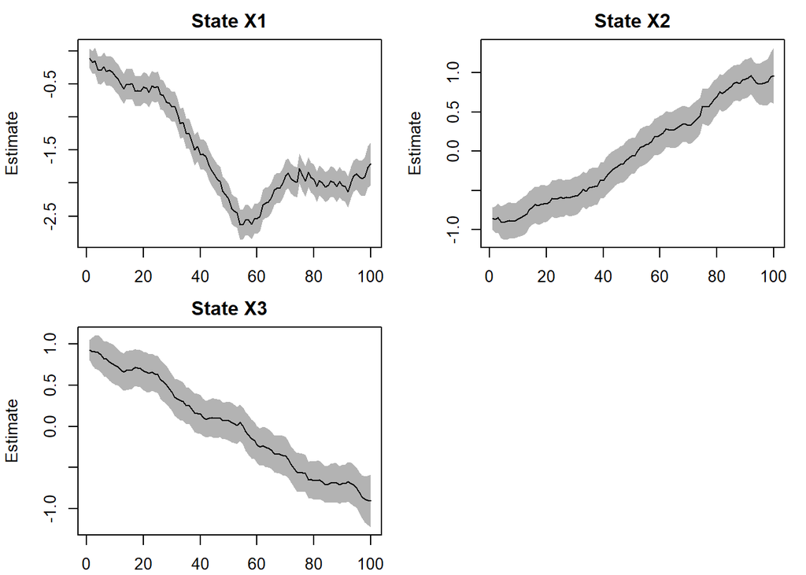

We can compare the estimated cycles to the ones used in the simulation.

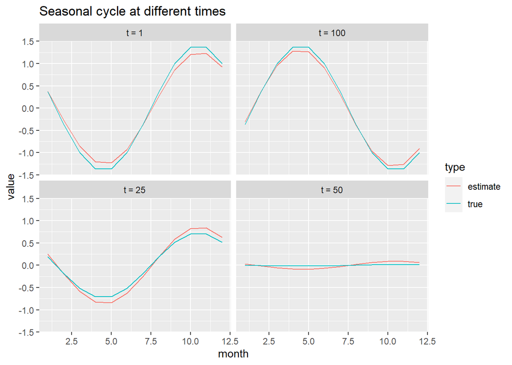

We can make this a bit harder by imagining that our data have missing values. Let’s imagine that we only observe half the months.

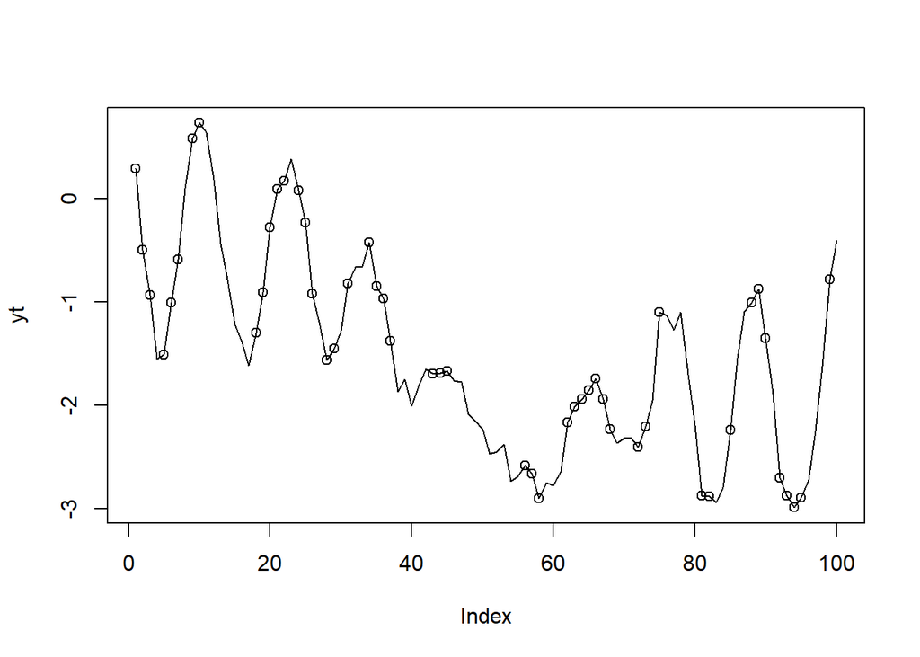

```r
yt.miss <- yt
yt.miss[sample(100, 50)] <- NA
plot(yt, type="l")
points(yt.miss)
```

```r
require(MARSS)
fit.miss <- MARSS(yt.miss, model=mod.list, inits=list(x0=matrix(0,3,1)))
```

```
## Success! abstol and log-log tests passed at 108 iterations.
## Alert: conv.test.slope.tol is 0.5.
## Test with smaller values (<0.1) to ensure convergence.
##
## MARSS fit is
## Estimation method: kem
## Convergence test: conv.test.slope.tol = 0.5, abstol = 0.001
## Estimation converged in 108 iterations.
## Log-likelihood: 0.1948933
## AIC: 13.61021   AICc: 16.27688
##
##           Estimate
## R.R        0.00243
## Q.(X1,X1)  0.01342
## Q.(X2,X2)  0.00794
## Q.(X3,X3)  0.00580
## x0.X1     -0.11497
## x0.X2     -0.82921
## x0.X3      0.92696
## Initial states (x0) defined at t=0
##
## Standard errors have not been calculated.
## Use MARSSparamCIs to compute CIs and bias estimates.
```

The model still can pick out the changing seasonal cycle.

```
## plot type = "xtT" Estimated States
```

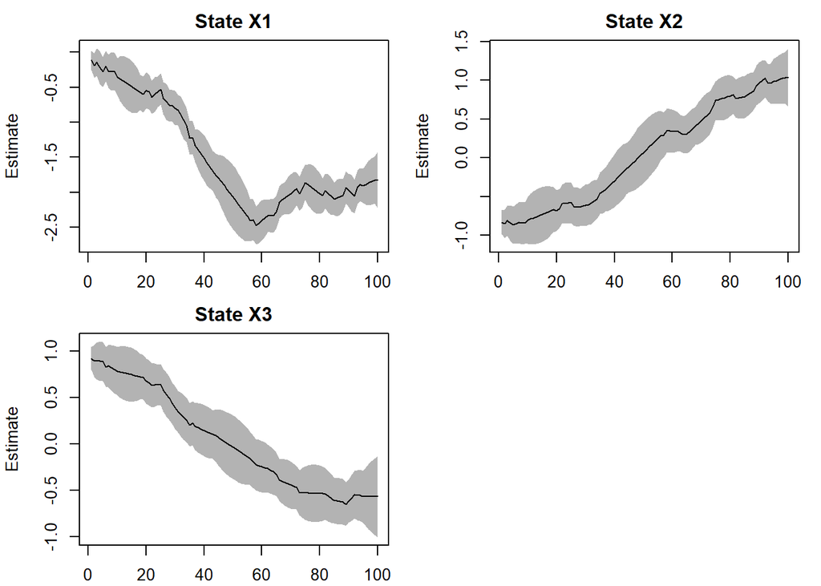

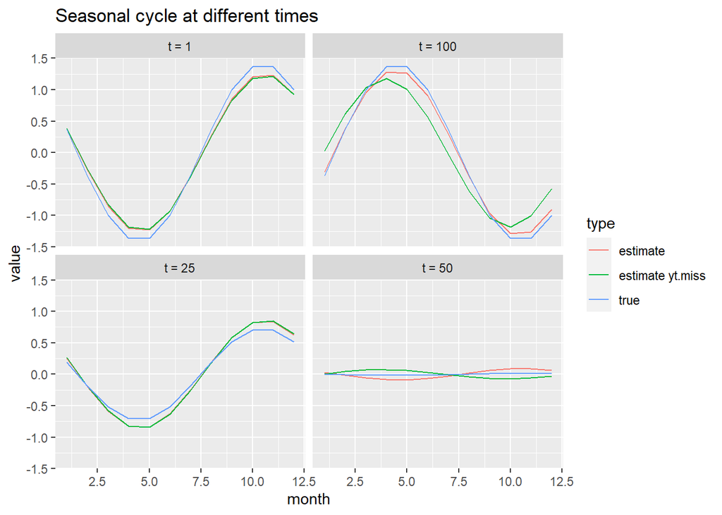

## Multivariate DLMs

Let’s imagine that we have two sites $y_1$ and $y_2$. We can model relationship between the seasonality in these two sites in many different ways. How we model it depends on our assumptions about our site or might reflect different relationships that we want to test.

### Same seasonality and same level

In this case $x_t$ is shared and the $\beta$’s. We can allow the data to be scaled (translated up or down) relative to each other however.

$$\begin{bmatrix}x \\ \beta_1 \\ \beta_2 \end{bmatrix}_t = \begin{bmatrix}x \\ \beta_1 \\ \beta_2 \end{bmatrix}_{t-1} + \begin{bmatrix}w_1 \\ w_2 \\ w_3 \end{bmatrix}_t$$

$$\begin{bmatrix}y_1 \\ y_2\end{bmatrix}_t = \begin{bmatrix}1& \sin(2\pi t/p)&\cos(2\pi t/p)\\1& \sin(2\pi t/p)&\cos(2\pi t/p)\end{bmatrix} \begin{bmatrix}x \\ \beta_1 \\ \beta_2 \end{bmatrix}_t + \begin{bmatrix}0 \\ a_2\end{bmatrix} + \begin{bmatrix}v_1 \\ v_2\end{bmatrix}_t$$

### Same seasonality and same level but scaled

Same as the model above but we allow that the $y$ level are stretched versions of $x$ (so $z x_t$) ). We only change one of the $y$ to have a scaled $x$ or else the model would have infinite number of solutions.

$$\begin{bmatrix}y_1 \\ y_2\end{bmatrix}_t = \begin{bmatrix}1& \sin(2\pi t/p)&\cos(2\pi t/p)\\z& \sin(2\pi t/p)&\cos(2\pi t/p)\end{bmatrix} \begin{bmatrix}x \\ \beta_1 \\ \beta_2 \end{bmatrix}_t + \begin{bmatrix}0 \\ a_2\end{bmatrix} + \begin{bmatrix}v_1 \\ v_2\end{bmatrix}_t$$
### Scaled seasonality and same level

We could also say that the are affect by the same seasonality but the amplitude is different. So covariate will be $z(\sin(2\pi t/12)+\cos(2\pi t/12))$ for the second $y$.

$$\begin{bmatrix}y_1 \\ y_2\end{bmatrix}_t = \begin{bmatrix}1& \sin(2\pi t/p)&\cos(2\pi t/p)\\1& z\sin(2\pi t/p)&z\cos(2\pi t/p)\end{bmatrix} \begin{bmatrix}x \\ \beta_1 \\ \beta_2 \end{bmatrix}_t + \begin{bmatrix}0 \\ a_2\end{bmatrix} + \begin{bmatrix}v_1 \\ v_2\end{bmatrix}_t$$

### Different seasonality but correlated

We might imagine that the seasonality is different between the sites but that the changes in seasonality are allowed to covary.

$$\begin{bmatrix}x \\ \beta_{1a} \\ \beta_{1b} \\ \beta_{2a} \\ \beta_{2b} \end{bmatrix}_t = \begin{bmatrix}x \\ \beta_{1a} \\ \beta_{1b} \\ \beta_{2a} \\ \beta_{2b} \end{bmatrix}_{t-1} + \begin{bmatrix}w \\ w_1 \\ w_2 \\w_3\\w_4 \end{bmatrix}_t$$

$$\begin{bmatrix}w \\ w_1 \\ w_2 \\w_3\\w_4 \end{bmatrix}_t \sim \text{MVN}\left(0, \begin{bmatrix}q & 0 & 0 & 0 & 0
\\ 0 & q_1 & c_1 & 0 & 0
\\ 0 & c_1 & q_1 & 0 & 0
\\ 0 & 0 & 0 & q_2 & c_2
\\ 0 & 0 & 0 & c_2 & q_2 \end{bmatrix} \right)$$

$$\begin{bmatrix}y_1 \\ y_2\end{bmatrix}_t = \begin{bmatrix}
1& \sin(2\pi t/p)&\cos(2\pi t/p) & 0 & 0
\\1& 0 & 0 & \sin(2\pi t/p)&\cos(2\pi t/p)
\end{bmatrix}
\begin{bmatrix}x \\ \beta_{1a} \\ \beta_{1b} \\ \beta_{2a} \\ \beta_{2b} \end{bmatrix}_t + \begin{bmatrix}0 \\ a_2\end{bmatrix} + \begin{bmatrix}v_1 \\ v_2\end{bmatrix}_t$$

### Same seasonality and different level

In this case there is a different $x_t$ for each $y_t$.

$$\begin{bmatrix}x_1 \\ x_2 \\ \beta_1 \\ \beta_2 \end{bmatrix}_t = \begin{bmatrix}x_1\\x_2 \\ \beta_1 \\ \beta_2 \end{bmatrix}_{t-1} + \begin{bmatrix}w_1 \\ w_2 \\ w_3\\w_4 \end{bmatrix}_t$$

$$\begin{bmatrix}y_1 \\ y_2\end{bmatrix}_t = \begin{bmatrix}1& 0&\sin(2\pi t/p)&\cos(2\pi t/p)\\0&1& \sin(2\pi t/p)&\cos(2\pi t/p)\end{bmatrix} \begin{bmatrix}x_1\\x_2 \\ \beta_1 \\ \beta_2 \end{bmatrix}_t + \begin{bmatrix}0 \\ a_2\end{bmatrix} + \begin{bmatrix}v_1 \\ v_2\end{bmatrix}_t$$